# Understanding college debt

I want to see what types of universities have students in debt. We will be using the college scorecard API from data.gov. I am interested in a number of variables, these are admissions rate, tuition, median household income, student size, etc.

It seems that the UC office of president [claims that the UC schools are a good deal](http://www.ucop.edu/institutional-research-academic-planning/_files/College%20Scorecard%20Brief.pdf) based on data from the college scorecard.

You should go begin by getting an [API key for data.gov](https://api.data.gov/signup/). There are many data.gov APIs that you can use this key for and they have fairly relaxed limits on the number of requests.

The documentation for the API can be found here...  
https://github.com/RTICWDT/open-data-maker/blob/master/API.md  
https://collegescorecard.ed.gov/data/

Let's import some packages.

```python
from urllib2 import Request, urlopen
import requests
import pandas as pd
import json
from matplotlib import pyplot as plt
import matplotlib as mp
plt.style.use('ggplot')
%matplotlib inline
```

Here are some variable names that we will be interested in.

```python
varnames = """id
school.name
school.degrees_awarded.predominant
2014.admissions.admission_rate.overall
2014.cost.tuition.in_state
2014.cost.tuition.out_of_state
2014.aid.median_debt.completers.overall
2014.aid.median_debt.noncompleters
2005.student.demographics.median_hh_income
2005.student.demographics.poverty_rate
2014.aid.federal_loan_rate
2014.aid.pell_grant_rate
2014.student.size"""
```

**Exercise (1)** I would like to make a complicated query from the API. An example query from the API is

```
https://api.data.gov/ed/collegescorecard/v1/schools.json?school.degrees_awarded.predominant=3&_fields=school.name,
2014.aid.pell_grant_rate&_sort=2014.student.size:desc&_page=1
&_per_page=100&api_key=YOURKEY
```

Which can be parsed as

1. the base url: https://api.data.gov/ed/collegescorecard/v1/schools.json,
2. a filter of school.degrees_awarded.predominant=3,
3. return the fields school.name,2014.aid.pell_grant_rate,
4. sort by 2014.student.size in descending order,
5. return 1 page of 100 entries,
6. and use your api key

You can find a more complete description: https://github.com/RTICWDT/open-data-maker/blob/master/API.md

Fill in the following def that fits the following docstring, and gives the shown output.

```
def query_url(key,fieldnames,filterstring,sortvar,numpages):
    """
    This takes all of the necessary parameters to form a query
    to college scorecard
    Input: key (data.gov API key, string), fieldnames (list of variable
      names), filterstring (string for filtering), sortvar (variable to
      sort with by descending), numpages (number of pages to return)
    Output: url (string)
    """


query_url(key,fieldnames,'school.degrees_awarded.predominant=3',
  '2014.student.size',2)

https://api.data.gov/ed/collegescorecard/v1/schools.json?school.degrees_awarded.predominant=3&_fields=id,school.name,school.degrees_awarded.predominant,school.degree_urbanization,2014.admissions.admission_rate.overall,2014.cost.tuition.in_state,2014.cost.tuition.out_of_state,2014.aid.median_debt.completers.overall,2014.aid.median_debt.noncompleters,2005.student.demographics.median_hh_income,2005.student.demographics.poverty_rate,2014.aid.federal_loan_rate,2014.aid.pell_grant_rate,2014.student.size&_page=2&_per_page=100&_sort=2014.student.size:desc&api_key=YOURKEYHERE
```

Try to reproduce the above behavior.

```python
key = "4y8emwdeDUa2nZkAdQRMN5sBhTu6g8Y1HtFL0fkM"

"""
filter string
fieldnames
page number
sortvar
key
"""

def query_url(key,fieldnames,filterstring,sortvar,numpages):
    """
    This takes all of the necessary parameters to form a query
    to college scorecard
    Input: key (data.gov API key, string), fieldnames (list of variable
      names), filterstring (string for filtering), sortvar (variable to
      sort with by descending), numpages (number of pages to return)
    Output: url (string)
    """
    url = "https://api.data.gov/ed/collegescorecard/v1/schools.json?%s&_fields=%s&_page=%d&_per_page=100&_sort=%s:desc&api_key=%s"
    qurl = url % (filterstring,fieldnames,numpages,sortvar,key)
    return qurl
fieldnames = varnames.replace('\n',',')
test = query_url(key,fieldnames,'school.degrees_awarded.predominant=3','2014.student.size',2)
```

```python
test
```

```
'https://api.data.gov/ed/collegescorecard/v1/schools.json?school.degrees_awarded.predominant=3&_fields=id,school.name,school.degrees_awarded.predominant,2014.admissions.admission_rate.overall,2014.cost.tuition.in_state,2014.cost.tuition.out_of_state,2014.aid.median_debt.completers.overall,2014.aid.m…
```

**Exercise (2)** Make the query using Request and load the results into a DataFrame that makes sense.

```python
r = requests.get(test)
```

```python
X = json.loads(r.text)
```

```python
list(X.keys())
```

```
[u'results', u'metadata']
```

```python
df = pd.DataFrame(X["results"])
df = df[df.columns[::-1]]
```

```python
df
```

|  | school.name | school.degrees_awarded.predominant | id | 2014.student.size | 2014.cost.tuition.out_of_state | 2014.cost.tuition.in_state | 2014.aid.pell_grant_rate | 2014.aid.median_debt.noncompleters | 2014.aid.median_debt.completers.overall | 2014.aid.federal_loan_rate | 2014.admissions.admission_rate.overall | 2005.student.demographics.poverty_rate | 2005.student.demographics.median_hh_income |
| --- | --- | --- | --- | --- | --- | --- | --- | --- | --- | --- | --- | --- | --- |
| 0 | Universidad Del Este | 3 | 243346 | 12198 | 5580 | 5580 | 0.8644 | 3275.0 | 6789.5 | 0.3931 | NaN | 43.689999 | 21682.0 |
| 1 | University of Massachusetts-Lowell | 3 | 166513 | 12190 | 27400 | 12447 | 0.2884 | 10422.0 | 25000.0 | 0.5744 | 0.6201 | 6.540000 | 76546.0 |
| 2 | CUNY City College | 3 | 190567 | 12175 | 13199 | 6389 | 0.5180 | 7000.0 | 11551.0 | 0.2225 | 0.3806 | 21.600000 | 48071.0 |
| 3 | New Mexico State University-Main Campus | 3 | 188030 | 12171 | 19112 | 5950 | 0.4191 | 7624.0 | 18340.0 | 0.4002 | 0.6960 | 17.799999 | 43867.0 |
| 4 | University of Massachusetts-Boston | 3 | 166638 | 12108 | 28390 | 11966 | 0.3857 | NaN | NaN | 0.5523 | 0.7077 | 9.010000 | 68463.0 |
| 5 | Wright State University-Main Campus | 3 | 206604 | 12090 | 16910 | 8730 | 0.3790 | 9500.0 | 25000.0 | 0.5498 | NaN | 6.550000 | 61970.0 |
| 6 | University of Puerto Rico-Rio Piedras | 3 | 243221 | 12086 | 4040 | 2019 | 0.5804 | 5500.0 | 5500.0 | 0.0858 | 0.2817 | 45.730000 | 20501.0 |
| 7 | Indiana University of Pennsylvania-Main Campus | 3 | 213020 | 12032 | 20965 | 9470 | 0.3666 | 11000.0 | 27000.0 | 0.7244 | 0.9473 | 7.800000 | 54158.0 |
| 8 | University of Nebraska at Omaha | 3 | 181394 | 11989 | 18070 | 6750 | 0.3260 | 8000.0 | 20000.0 | 0.4500 | 0.7850 | 5.360000 | 66043.0 |
| 9 | Saint Leo University | 3 | 137032 | 11976 | 20420 | 20420 | 0.4828 | 9500.0 | 25000.0 | 0.6032 | 0.7216 | 8.880000 | 58178.0 |
| 10 | University of Southern Mississippi | 3 | 176372 | 11939 | 15550 | 6980 | 0.4865 | 10935.5 | 25000.0 | 0.6600 | 0.6674 | 14.440000 | 46990.0 |
| 11 | Kean University | 3 | 185262 | 11938 | 17653 | 11244 | 0.4308 | 11000.0 | 24500.0 | 0.6212 | 0.7036 | 7.520000 | 76062.0 |
| 12 | North Dakota State University-Main Campus | 3 | 200332 | 11763 | 18969 | 7940 | 0.2143 | 7300.0 | 24000.0 | 0.5492 | 0.8274 | 6.590000 | 55831.0 |
| 13 | Rowan University | 3 | 184782 | 11690 | 20570 | 12616 | 0.2974 | 12000.0 | 21500.0 | 0.5673 | 0.4357 | 5.760000 | 76692.0 |
| 14 | Northern Kentucky University | 3 | 157447 | 11654 | 17328 | 8856 | 0.3416 | 8250.0 | 24184.0 | 0.5413 | 0.9072 | 6.910000 | 63568.0 |
| 15 | Universidad Metropolitana | 3 | 241739 | 11529 | 5580 | 5580 | 0.8601 | 3367.0 | 7500.5 | 0.4295 | NaN | 40.020000 | 24604.0 |
| 16 | California State University-San Marcos | 3 | 366711 | 11506 | 18329 | 7169 | 0.4544 | 11000.0 | 18000.0 | 0.4107 | 0.6180 | 7.220000 | 72827.0 |
| 17 | University of Alabama at Birmingham | 3 | 100663 | 11383 | 17062 | 7510 | 0.3460 | 10000.0 | 21941.5 | 0.5214 | 0.8569 | 10.910000 | 55735.0 |
| 18 | Southern Illinois University-Edwardsville | 3 | 149231 | 11371 | 20682 | 9738 | 0.3621 | 9186.0 | 21875.0 | 0.5999 | 0.8696 | 7.140000 | 59952.0 |
| 19 | Arizona State University-Skysong | 3 | 483124 | 11340 | 15137 | 8503 | 0.4215 | 9500.0 | 20229.0 | 0.6622 | 0.6091 | NaN | NaN |
| 20 | Cleveland State University | 3 | 202134 | 11308 | 12928 | 9686 | 0.4318 | 9750.0 | 22656.0 | 0.6196 | 0.8421 | 9.920000 | 57782.0 |
| 21 | Fort Hays State University | 3 | 155061 | 11298 | 13159 | 4469 | 0.2846 | 7250.0 | 20220.0 | 0.4054 | 0.8789 | 7.440000 | 50801.0 |
| 22 | Wichita State University | 3 | 156125 | 11297 | 15299 | 7265 | 0.3636 | 9500.0 | 21000.0 | 0.5096 | 0.9553 | 6.900000 | 60078.0 |
| 23 | University of Maryland-Baltimore County | 3 | 163268 | 11274 | 22682 | 10384 | 0.2742 | 11750.0 | 21943.0 | 0.4190 | 0.5961 | 4.920000 | 83010.0 |
| 24 | University of South Alabama | 3 | 102094 | 11267 | 14076 | 7188 | 0.3906 | 9294.0 | 24711.0 | 0.5729 | 0.8335 | 12.500000 | 51919.0 |
| 25 | Southeastern Louisiana University | 3 | 160612 | 11199 | 19111 | 6547 | 0.3652 | 6500.0 | 21313.0 | 0.4231 | 0.8373 | 12.910000 | 53084.0 |
| 26 | East Tennessee State University | 3 | 220075 | 11162 | 24011 | 7667 | 0.4331 | 9500.0 | 20000.0 | 0.5140 | 0.9174 | 10.490000 | 47640.0 |
| 27 | University of North Dakota | 3 | 200280 | 10978 | 18409 | 7741 | 0.2045 | 10500.0 | 24000.0 | 0.5067 | 0.8600 | 7.340000 | 56722.0 |
| 28 | The University of Montana | 3 | 180489 | 10969 | 22372 | 6099 | 0.3803 | 9750.0 | 23431.0 | 0.5327 | 0.9272 | 9.840000 | 50573.0 |
| 29 | University of Puerto Rico-Mayaguez | 3 | 243197 | 10914 | 4041 | 2019 | 0.6158 | 5500.0 | 6550.0 | 0.1703 | 0.7603 | 45.730000 | 20501.0 |
| ... | ... | ... | ... | ... | ... | ... | ... | ... | ... | ... | ... | ... | ... |
| 70 | CUNY Lehman College | 3 | 190637 | 9417 | 13218 | 6408 | 0.5310 | 5500.0 | 10000.0 | 0.2199 | 0.2891 | 26.530001 | 41652.0 |
| 71 | Southeast Missouri State University | 3 | 179557 | 9382 | 12450 | 7058 | 0.3487 | 8508.0 | 22105.0 | 0.4826 | 0.8478 | 10.100000 | 51305.0 |
| 72 | Idaho State University | 3 | 142276 | 9370 | 19326 | 6566 | 0.4315 | 10064.0 | 22500.0 | 0.4923 | NaN | 8.970000 | 52463.0 |
| 73 | Texas Woman's University | 3 | 229179 | 9327 | 18696 | 7836 | 0.4533 | 9476.5 | 20000.0 | 0.5573 | 0.8531 | 8.200000 | 69739.0 |
| 74 | Indiana University-Purdue University-Fort Wayne | 3 | 151102 | 9314 | 19092 | 7949 | 0.3262 | 9500.0 | 25500.0 | 0.4363 | 0.9087 | 5.690000 | 61940.0 |
| 75 | University of Colorado Colorado Springs | 3 | 126580 | 9310 | 17494 | 7462 | 0.3183 | 7433.0 | 21187.5 | 0.4730 | 0.9240 | 5.400000 | 70639.0 |
| 76 | Valdosta State University | 3 | 141264 | 9235 | 16459 | 6142 | 0.4693 | 13000.0 | 25247.0 | 0.6520 | 0.5414 | 10.740000 | 57353.0 |
| 77 | University of Central Arkansas | 3 | 106704 | 9232 | 13806 | 7889 | 0.4101 | 8250.0 | 21500.0 | 0.5125 | 0.9426 | 11.230000 | 48705.0 |
| 78 | SUNY Buffalo State | 3 | 196130 | 9185 | 16997 | 7347 | 0.4952 | 9500.0 | 21500.0 | 0.6549 | 0.6155 | 10.490000 | 55484.0 |
| 79 | Arkansas State University-Main Campus | 3 | 106458 | 9139 | 13480 | 7720 | 0.4522 | 8593.0 | 19250.0 | 0.5342 | 0.7239 | 13.390000 | 42159.0 |
| 80 | University of Minnesota-Duluth | 3 | 174233 | 9120 | 16467 | 12802 | 0.2417 | 8750.0 | 25190.0 | 0.5838 | 0.7678 | 4.950000 | 68076.0 |
| 81 | Arizona State University-Downtown Phoenix | 3 | 448886 | 9113 | 24503 | 10157 | 0.4088 | 9500.0 | 20229.0 | 0.5786 | 0.7886 | NaN | NaN |
| 82 | Bloomsburg University of Pennsylvania | 3 | 211158 | 9109 | 19364 | 8914 | 0.3029 | 8125.0 | 26000.0 | 0.6925 | 0.8781 | 6.550000 | 60832.0 |
| 83 | University of Northern Colorado | 3 | 127741 | 9104 | 19277 | 7733 | 0.3386 | 8000.0 | 22500.0 | 0.5672 | 0.7088 | 5.500000 | 72445.0 |
| 84 | Texas A & M University-Corpus Christi | 3 | 224147 | 9074 | 16283 | 7655 | 0.4094 | 9000.0 | 23000.0 | 0.5399 | 0.8462 | 13.210000 | 54287.0 |
| 85 | Coastal Carolina University | 3 | 218724 | 9058 | 23660 | 10320 | 0.3921 | 7500.0 | 25000.0 | 0.7055 | 0.6360 | 7.450000 | 64299.0 |
| 86 | Lamar University | 3 | 226091 | 9043 | 16362 | 7659 | 0.4420 | 9500.0 | 22486.0 | 0.5428 | 0.7881 | 12.420000 | 53474.0 |
| 87 | University of Central Missouri | 3 | 176965 | 9017 | 13659 | 7265 | 0.3664 | 9500.0 | 22983.0 | 0.6013 | 0.7795 | 7.530000 | 57730.0 |
| 88 | Austin Peay State University | 3 | 219602 | 9003 | 21664 | 7168 | 0.5244 | 10500.0 | 23202.0 | 0.5781 | 0.8927 | 8.930000 | 52472.0 |
| 89 | University of Missouri-St Louis | 3 | 178420 | 8936 | 23142 | 8844 | 0.2927 | 12139.0 | 21113.5 | 0.4073 | 0.7578 | 7.570000 | 64068.0 |
| 90 | Columbia College-Chicago | 3 | 144281 | 8929 | 23544 | 23544 | 0.3808 | 10500.0 | 26000.0 | 0.6929 | 0.8853 | 7.530000 | 72555.0 |
| 91 | North Carolina A & T State University | 3 | 199102 | 8894 | 18402 | 5642 | 0.6091 | 18500.0 | 28500.0 | 0.7947 | 0.5700 | 10.730000 | 56398.0 |
| 92 | University of Wisconsin-Stevens Point | 3 | 240480 | 8880 | 15241 | 7668 | 0.3394 | 7250.0 | 24922.0 | 0.6503 | 0.8941 | 4.530000 | 62211.0 |
| 93 | Marshall University | 3 | 237525 | 8871 | 15026 | 6526 | 0.4321 | 9500.0 | 22705.0 | 0.5930 | 0.7653 | 13.220000 | 45141.0 |
| 94 | Johnson & Wales University-Providence | 3 | 217235 | 8846 | 28539 | 28539 | 0.3374 | 9980.0 | 27000.0 | 0.7882 | 0.8115 | 7.850000 | 68856.0 |
| 95 | Savannah College of Art and Design | 3 | 140951 | 8846 | 34295 | 34295 | 0.2663 | 8334.0 | 27000.0 | 0.5142 | 0.6655 | 7.020000 | 71588.0 |
| 96 | Arkansas Tech University | 3 | 106467 | 8845 | 10878 | 5862 | 0.4447 | 7500.0 | 17480.0 | 0.4517 | 0.8626 | 11.610000 | 43602.0 |
| 97 | Radford University | 3 | 233277 | 8843 | 22046 | 9360 | 0.2896 | 8219.0 | 21500.0 | 0.5990 | 0.7891 | 6.240000 | 67375.0 |
| 98 | Texas A & M University-Kingsville | 3 | 228705 | 8815 | 18984 | 7554 | 0.5027 | 9523.0 | 20000.0 | 0.5997 | 0.8357 | 19.010000 | 45266.0 |
| 99 | Capella University | 3 | 413413 | 8738 | 12816 | 12816 | 0.5505 | 8228.0 | 30312.5 | 0.8465 | NaN | 7.920000 | 64334.0 |

100 rows × 13 columns

**Exercise (3)** Produce scatterplots to demonstrate the associations between student debt (for 'completers') and median household income, pell grant rates, student poverty rate, tuition, and federal loan rate. Do you have an explanation for the associations that you are seeing? Are there some surprising associations.

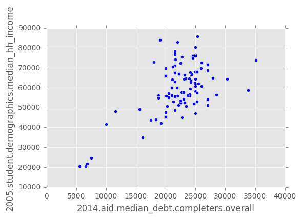

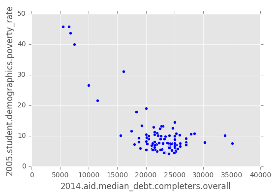

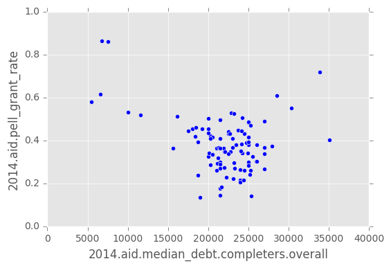

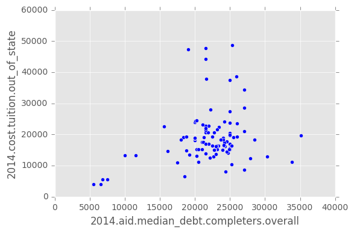

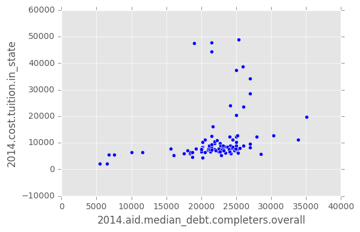

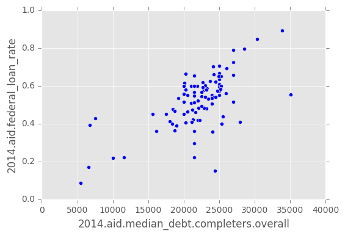

```python
def generatescatters(df):
    mylist = [12,11,6,4,5,9]
    for i in mylist:
        plt.scatter(df["2014.aid.median_debt.completers.overall"],df.ix[:,i])
        plt.xlabel("2014.aid.median_debt.completers.overall")
        plt.ylabel(df.columns[i])
        plt.show()
    return
generatescatters(df)
```